# Εργασία 3

Παναγίωτης Δημητρίου

2026-04-28

## ΑΣΚΗΣΗ 1

Γνωρίζουμε από ΙΝΜΑ ότι ο εκτιμητης Monte-Carlo $Z_n^{MC} \to \mathbb{E}[h(X)]$ όπου Xj ακολουθούν την $F$. Σε αυτή την περίπτωση έχουμε ότι $Xj\sim Exp(2)$ και $h(x) = \sin(x) \log^3(x)$. Αρχικά εκτιμήσαμε την διασπορά με την εντολή της R var() για τυχαίο δείγμα μεγέθους m=100000 από την Exp(2). Έπειτα, επειδή $MSE(z_n^{MC}) = \frac{Var(h(X))}{n}$, και θέλουμε επιθυμητό σφάλμα της τάξης του $\epsilon > 0$, τότε
$$\frac{Var(h(X))}{n} < \epsilon^2 \implies n
\ge \frac{Var(h(X))}{\epsilon^2} \quad (1)$$
Ισχύει ότι
$$RMSE(z_n^{MC}) = \sqrt{MSE(z_n^{MC})} =
\frac{\sqrt{Var(h(X))}}{\sqrt{n}} \sim \text{σφάλμα}$$
και έτσι θα βρούμε την κατάλληλη τιμή n που είναι το μέγεθος του δείγματος για να προσομειώσουμε απο την Exp(2) έτσι ώστε να βγάζουμε ένα Monte-Carlo.

```r
mctheta=function(N,eps){

  if(N<=0 || N%%1!=0){
    stop("Το N θα πρέπει να είναι θετικός ακέραιος")
  }
  if(eps<=0){
    stop("Το eps θα πρέπει να είναι θετικός")
  }
  x1=rexp(100000,2)
  x2=sin(x1)*(log(x1))^3 #εκτίμηση του var(h(X))
  esvar=var(x2)

  n=ceiling(esvar/eps) #αφού n>=var(h(X))/ε^2 τότε παίρνω ceiling για τον επόμενο ακέραιο n που ισχυεί για το επιθημητό σφάλμα ε και βρίσκουμε το πλήθος n τετοιό ώστε το RMSE<ε
  sim.MC=c()
  for(i in 1:N){ #εκτελούμε το MC πείραμα Ν φορές
  z=rexp(n,2)
  mc=mean(sin(z)*log(z)^3) #υπολογισμός Monte-Carlo εκτιμητή με Ζ να ακολουθούν την Exp(2) μεγέθους n στο πλήθος, όπως αυτό υπολογίστηκε στο προηγούμενο στάδιο για να έχουμε RMSE<ε
  sim.MC[i]=mc #διάνυσμα από της Ν εκτιμήσεις Monte-Carlo
  }

  return(list(vector=sim.MC,sample.size=n))
}
```

```r
set.seed(1)
z1=mctheta(100,0.01)
z2=mctheta(100,0.001)
z3=mctheta(100,0.0001)
```

Γενικά από την $(1)$ αναμένουμε ότι καθώς το ε γίνεται μικρότερο τότε θέλουμε μεγαλύτερο δείγμα προσομείωσης.

Η Monte-Carlo εκτιμήτρια $z_n^{MC}$ του $\mathbb{E}[h(X)]$ είναι αμερόληπτη ($\mathbb{E}(z_n^{MC}) = \mathbb{E}[h(X)] \iff bias(z_n^{MC}) = 0$) και έχει μέσο τετραγωνικό σφάλμα:

$$MSE(z_n^{MC}) = Var(z_n^{MC}) =
\frac{1}{n} Var(h(X))$$

**Απόδειξη:**

$$\begin{aligned}
\mathbb{E}(z_n^{MC}) &= \mathbb{E}\left(\frac{1}{n} \sum_{j=1}^{n}
h(X_j)\right) \\
&= \frac{1}{n} \sum_{j=1}^{n} \mathbb{E}(h(X_j)) \stackrel{iid}{=}
\frac{1}{n} n \cdot \mathbb{E}[h(X)] = \mathbb{E}[h(X)]
\end{aligned}$$

Για το MSE (εκτιμητής για σφάλμα στο τετράγωνο / τετράγωνο του σφάλματος) έχουμε το ακόλουθο:

$$\begin{aligned}
MSE(z_n^{MC}) &= Var(z_n^{MC}) = Var\left(\frac{1}{n} \sum_{j=1}^{n}
h(X_j)\right) \\
&\stackrel{iid}{=} \frac{1}{n^2} \sum_{j=1}^{n} Var(h(X)) =
\frac{n}{n^2} Var(h(X)) = \frac{1}{n} Var(h(X))
\end{aligned}$$
Και απο Κεντρικό Οριακό Θεώρημα ισχύει.
$$Z_n^{MC} \sim N\left(\mathbb{E}[h(X)],
\frac{Var(h(X))}{n}\right)$$

```r
mcn1=z1$vector
n1=z1$sample.size
n1 #χρειαστίκαμε δείγμα μήκους n=26 για το ε=0.01
```

```
## [1] 26
```

```r
mcn2=z2$vector
n2=z2$sample.size
n2
```

```
## [1] 255
```

```r
mcn3=z3$vector
n3=z3$sample.size
n3
```

```
## [1] 2547
```

Πιο κάτω θα κάνουμε τα αντίστοιχα ιστογράμματα για το κάθε διάνυσμα που βγάλαμε έχοντας τον ίδιο αριθμό Μonte-Carlo πειραμάτων(N=100).

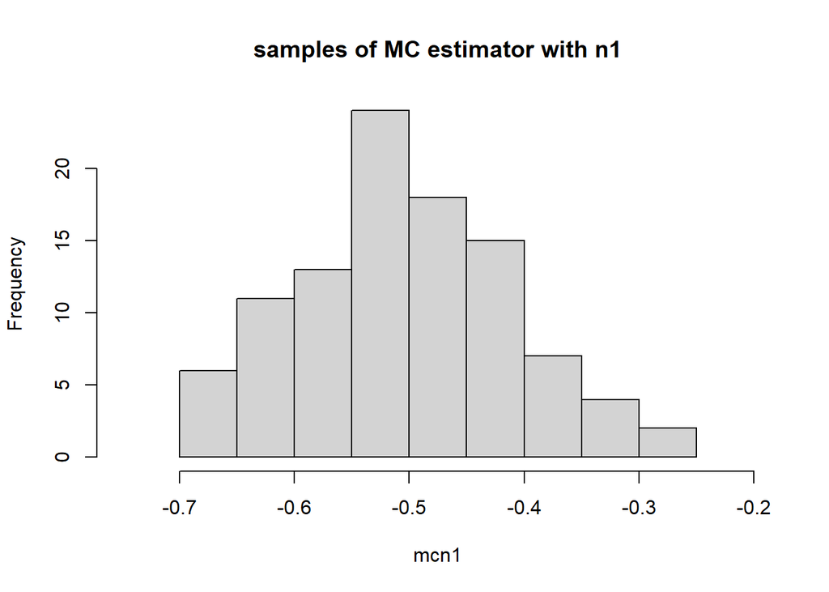

```r
hist(mcn1, breaks = 15,xlim=c(-0.75,-0.2),main="samples of MC estimator with n1")
```

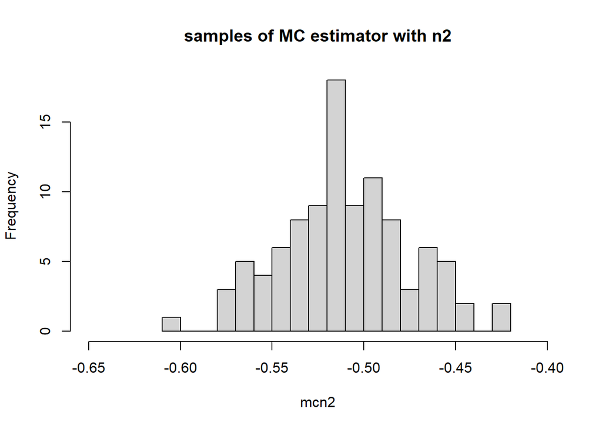

```r
hist(mcn2, breaks = 15,xlim=c(-0.65,-0.4),main="samples of MC estimator with n2")
```

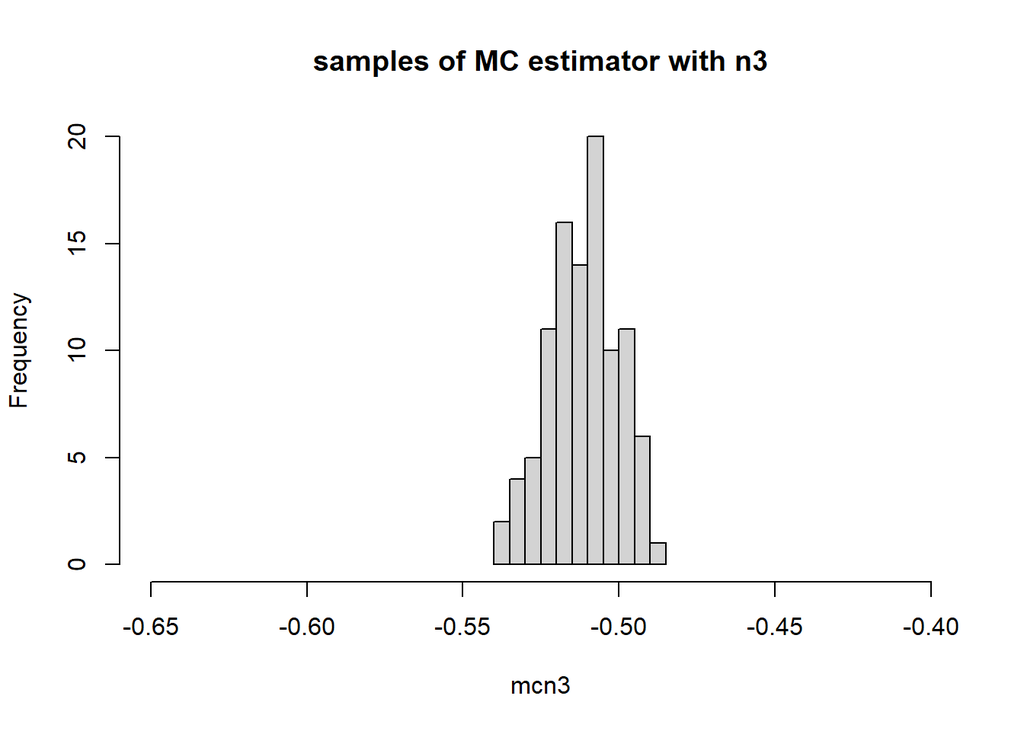

```r
hist(mcn3, breaks = 15,xlim=c(-0.65,-0.4),main="samples of MC estimator with n3")
```

Βλέπουμε ότι όπως περιμέναμε από τη θεωρία, καθώς το n μεγαλώνει τα δείγματα συγκεντρώνονται γύρω από μια μέση τιμή και η διακύμανση ελαττώνεται κατά $1/n$. Με την αλλαγή του κάθε δείγματος που αντιστοιχεί σε διαφορετικό n το οποίο μεγαλώνει έχουμε “καλύτερο” ιστόγραμμα αφού η κατανομή της εκτιμήτριας συγκλίνει προς την κανονική όπως αναμέναμε.

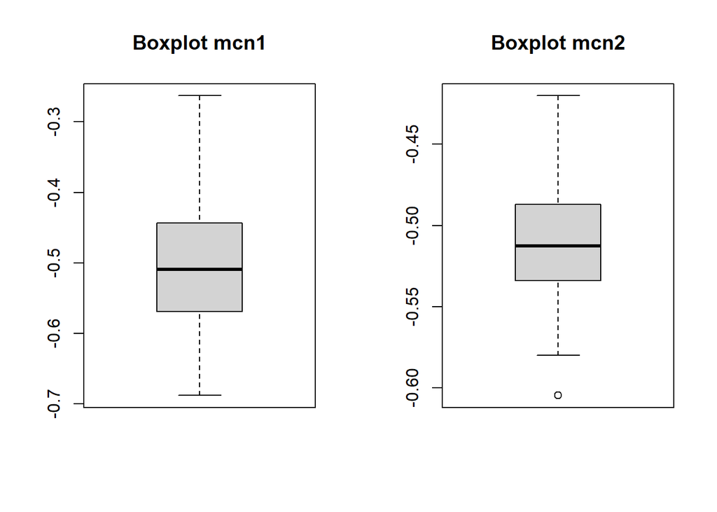

```r
par(mfrow=c(1,2))
boxplot(mcn1,main="Boxplot mcn1")
boxplot(mcn2,main="Boxplot mcn2")
```

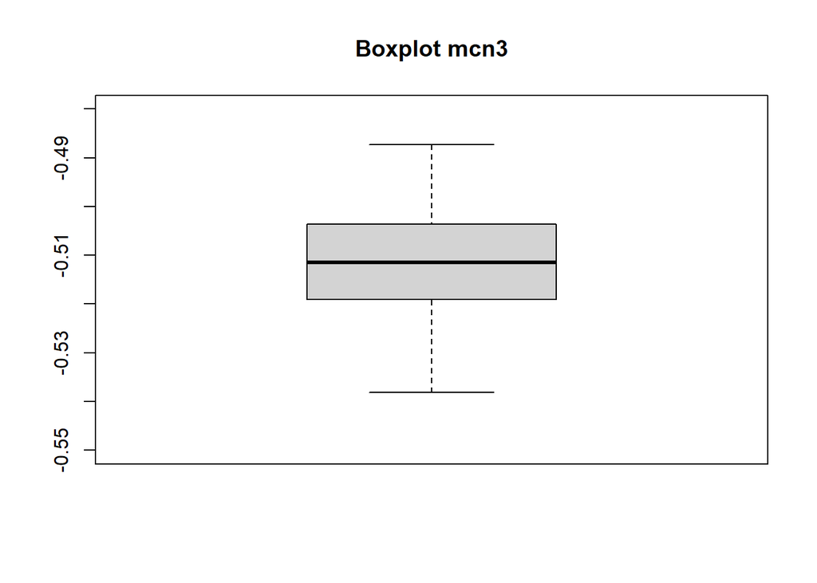

```r
par(mfrow=c(1,1))
boxplot(mcn3,ylim=c(-0.55,-0.48),main="Boxplot mcn3")
```

```r
smcn1=scale(mcn1)
ks.test(smcn1,"pnorm")
```

```
##
##  Asymptotic one-sample Kolmogorov-Smirnov test
##
## data:  smcn1
## D = 0.055383, p-value = 0.9189
## alternative hypothesis: two-sided
```

```r
smcn2=scale(mcn2)
ks.test(smcn2, 'pnorm')
```

```
##
##  Asymptotic one-sample Kolmogorov-Smirnov test
##
## data:  smcn2
## D = 0.054664, p-value = 0.9262
## alternative hypothesis: two-sided
```

```r
smcn3=scale(mcn3)
ks.test(smcn3, 'pnorm')
```

```
##
##  Asymptotic one-sample Kolmogorov-Smirnov test
##
## data:  smcn3
## D = 0.037347, p-value = 0.999
## alternative hypothesis: two-sided
```

Κανονικοποιήσαμε το διάνυσμα μας και με την Kolmogorov-Smirnov παρατηρούμε ότι το smcn1(n=26) και το smcn2(n=255) ενώ είχαν εξαιρετικό p-value 0.9189 και 0.9262 αντίστοιχα, που σημαίνει ότι ακολουθούν την κανονική το smcn3 είναι ακόμη πιο τέλειο.

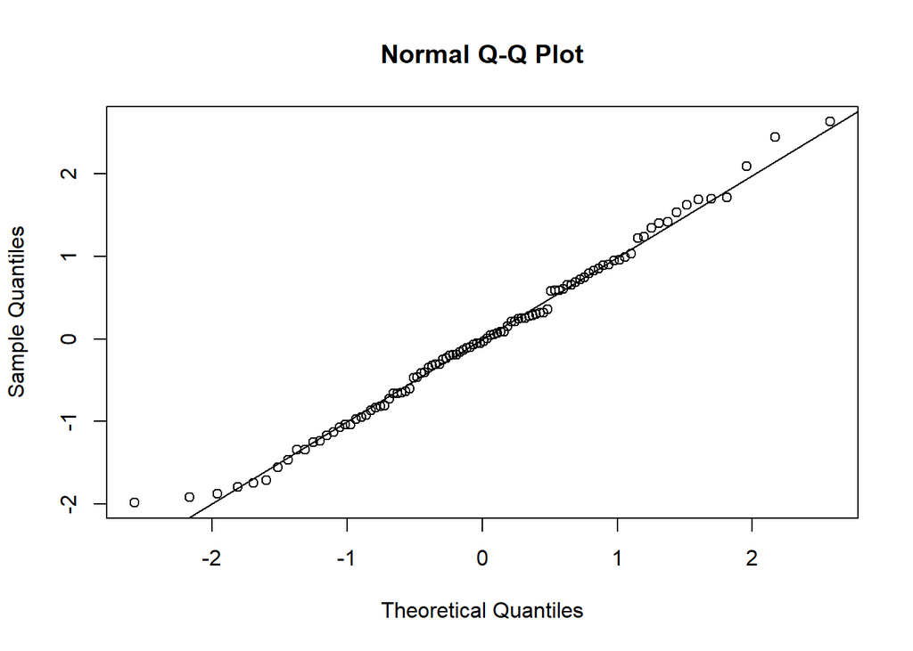

```r
qqnorm(smcn1)
qqline(smcn1)
```

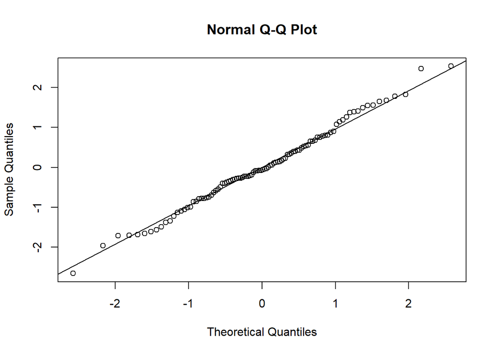

```r
qqnorm(smcn2)
qqline(smcn2)
```

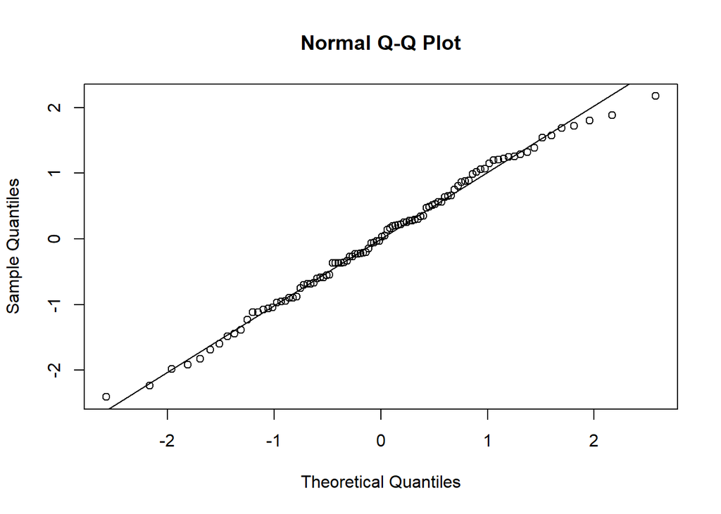

```r
qqnorm(smcn3)
qqline(smcn3)
```

Επίσης απο το qqplots βλέπουμε ότι στις πρώτες δύο περιπτώσεις είχαμε τα σημεία μας είχαν πιο μεγάλη απόσταση απο την τελευταία περίπτωση.

```r
var(mcn1)/var(mcn2)
```

```
## [1] 6.702366
```

```r
var(mcn1)/var(mcn3)
```

```
## [1] 68.75365
```

```r
var(mcn2)/var(mcn3)
```

```
## [1] 10.25812
```

Από όλα αυτά επιβεβαιώνουμε την σύγκλιση της Monte-Carlo εκτιμήτριας προς την κανονική κάθως το n μεγαλώνει αλλά και την μείωση της διασποράς απο το προηγούμενο πηλίκο που το αποδεικνύει.

## ΑΣΚΗΣΗ 2

Θέλετε να υπολογίσετε τη μέση τιμή $E[h(X)]$ για την τυχαία μεταβλητή X∼N(0,1) με συνάρτηση
$$h(x) = e^{-\frac{(x-3)^2}{2}}
+ e^{-\frac{(x-6)^2}{2}}$$

(β) Γράψτε ένα πρόγραμμα στην R για να την εκτιμήσετε χρησιμοποιώντας δείγμα μεγέθους $n = 10^3$ και υπολογίστε το σφάλμα.

```r
set.seed(123)
n = 1000
x = rnorm(n,0,1) #δημιουργούμε ένα δείγμα από την κανονική κατανομή

h =function(x){
  exp(-(x-3)^2 / 2) + exp(-(x-6)^2 / 2)
}

h_values = h(x) #υπολογισμός των h(x)
mc_estimate = mean(h_values) #υπολογισμός Monte Carlo εκτίμησης της θεωρητικής ποσότητας μ=Ε[h(x)].

#Υπολογισμός του τυπικού σφάλματος (Standard Error)
#Το σφάλμα της Monte Carlo εκτίμησης είναι s / sqrt(n)
standard_error = sd(h_values) / sqrt(n)

# Εκτύπωση αποτελεσμάτων
cat("Εκτίμηση Monte Carlo:", mc_estimate, "\n")
```

```
## Εκτίμηση Monte Carlo: 0.07699182
```

```r
cat("Τυπικό Σφάλμα:", standard_error, "\n")
```

```
## Τυπικό Σφάλμα: 0.005086384
```

(γ) Υπολογείστε τη μέση τιμή, γράφοντας ένα πρόγραμμα στην R με τη χρήση του Importance Sampling και χρησιμοποιώντας ως proposal g την N(2.5,2) μία μίξη κανονικών $1/2*N(1.5,0.5) + 1/2*N(3,0.5)$ καθώς και την ομοιόμορφη U(−8,−1) και δείγμα μεγέθους $N = 10^3$.

Ποια proposal έχει την καλύτερη απόδοση;

Θα ορίσουμε πρώτα τις συναρτήσεις h(x) και f(x).

```r
set.seed(42)
N=1000
# ορίζω τα h(x) και f(x)
h = function(x){
  exp(-(x - 3)^2 / 2) + exp(-(x - 6)^2 / 2)}
f =function(x){
  dnorm(x,0,1)}
```

Γενικά, ισχύει
$$(1) RMSE(z_n^{IS}) =
\sqrt{Var(z_n^{IS})}=\frac{\sqrt{Var\left(h(X_j) \frac{f(X_j)}{g(X_j)}\right)}}{\sqrt{n}}$$

Το οποίο είναι το σφάλμα

Άρα η Proposal που δίνει την μικρότερη διακύμανση τότε θα έχουμε το μικρότερο σφάλμα(το n θα είναι 1000) άρα και καλύτερη απόδοση.

# Proposal 1: N(2.5, 2)

```r
imps1=function(n){

prop1_samples = rnorm(n, 2.5, sqrt(2))
weights1 = (h(prop1_samples) * f(prop1_samples)) / dnorm(prop1_samples, 2.5,sqrt(2))

return(mean(weights1))
}
```

```r
v1=c()
for(i in 1:1000){
  v1[i]=imps1(1000)

}
```

```r
estim.is1=mean(v1)
estim.is1 #εκτίμιση μέσης τιμής με την proposal 1
```

```
## [1] 0.07449862
```

```r
var1=var(v1)
var1
```

```
## [1] 5.41721e-06
```

# Proposal 2: Mixture 0.5*N(1.5, 0.5) + 0.5*N(3, 0.5)

```r
imps2=function(n){
prop2_samples = 1/2*rnorm(n, 1.5, sqrt(0.5))+1/2*rnorm(n, 3, sqrt(0.5))
g2_pdf = 0.5 * dnorm(prop2_samples, 1.5, sqrt(0.5)) + 0.5 * dnorm(prop2_samples, 3, sqrt(0.5))
weights2 = (h(prop2_samples) * f(prop2_samples)) / g2_pdf
return(mean(weights2))
}
```

```r
v2=c()
for(i in 1:1000){
  v2[i]=imps2(1000)

}
```

```r
estim.is2=mean(v2)
estim.is2
```

```
## [1] 0.07459923
```

```r
var2=var(v2)
var2
```

```
## [1] 1.563113e-06
```

# Proposal 3: U(-8, -1)

Η ομοιόμορφη $U(-8,-1)$ δεν αποτελεί κατάλληλη proposal κατανομή, διότι δεν καλύπτει την περιοχή όπου η $h(x)f(x)$ παίρνει σημαντικές τιμές, άρα παραβιάζει τη βασική προϋπόθεση του Importance Sampling.

Αυτό συμβαίνει επειδή f(x)>0 για κάθε x∈R και h(x)>0 για κάθε x∈R, επομένως h(x)f(x)>0 για κάθε x∈R, με αποτέλεσμα να πρέπει η proposal κατανομή μας να παίρνει θετικές τιμές σχεδόν παντού στα σημεία αυτά, πράγμα που δεν ισχύει σε αυτή την περίπτωση.

Συγκεκριμένα, μηδενίζεται σε περιοχές (όπως γύρω από το 3 και το 6) όπου το γινόμενο $h(x)f(x)$ παίρνει σημαντικές θετικές τιμές, παραβιάζοντας έτσι τη βασική θεωρητική προϋπόθεση του Importance Sampling ($g(x) > 0$ όταν $h(x)f(x) \neq 0$).

Ας το επιβεβαιώσουμε και μέσω των πιο κάτω αποτελεσμάτων:

```r
imps3=function(n){
prop3_samples = runif(N,-8,-1)
g3_pdf = dunif(prop3_samples,-8,-1)
weights2 = (h(prop3_samples) * f(prop3_samples)) / g3_pdf
return(mean(weights2))
}
```

```r
v3=c()
for(i in 1:1000){
  v3[i]=imps3(1000)

}
```

```r
estim.is3=mean(v3)
estim.is3
```

```
## [1] 1.518462e-05
```

```r
var3=var(v3)
var3
```

```
## [1] 4.276662e-12
```

Η ακαταλληλότητα της τρίτης proposal κατανομής $g$ επιβεβαιώνεται από τη μέση τιμή που είναι πολύ μακριά από την θεωρητική μέση τιμή και την διακύμανση που είναι σχεδόν 0, γεγονός που οδηγεί σε λάθος εκτιμητή. Επειδή η $h(x)$ στο διάστημα $[-8, -1]$ είναι πρακτικά 0, όλα τα δείγματα έδωσαν αποτέλεσμα 0.

Συνεπώς, η $U(-8,-1)$ παρουσιάζει κακή απόδοση και αποτέλει λανθασμένη επιλογή.

Πιο κάτω μπορούμε να δούμε πιο καθαρά τα αποτελέσματα που προκύπτουν από τις τρεις proposal g μέσω της χρήσης του Importance Sampling:

```r
results=data.frame(
  Proposal = c("N(2.5, 2)", "Mixture Normal","U(-8,-1)"),
  Variance_of_Est=c(var1,var2,var3)
)

print(results)
```

```
##         Proposal Variance_of_Est
## 1      N(2.5, 2)    5.417210e-06
## 2 Mixture Normal    1.563113e-06
## 3       U(-8,-1)    4.276662e-12
```

```r
var1/var2
```

```
## [1] 3.465655
```

Η διακύμανση var2 που αντιστοιχεί στην Mixture Normal είναι 3.5 φορές μικρότερη από την var1 της N(2.5,2).

Eπομένως από την σχέση (1) έχουμε ότι: Από τον πίνακα των διακυμάνσεων φαίνεται ότι η καλύτερη απόδοση επιτυγχάνεται με την Mixture Normal κατανομή, καθώς παρουσιάζει το μικρότερο σφάλμα (variance) ανάμεσα στις έγκυρες επιλογές (1.56e-06). Η ομοιόμορφη κατανομή $U(-8,-1)$ δίνει μηδενική διακύμανση (4.27e-12), διότι παίρνει δειγματα σε περιοχή όπου η συνάρτηση μηδέν, οδηγώντας σε έναν λανθασμένο εκτιμητή.